# Reproducible Research Assignment 1

Kevin Creese

Wednesday, September 16, 2015

## Summary

This report is an R Markdown file that describes the process used to compile data presented in the first assignment of **Coursera’s Reproducible Research**. Throughout this assignment we will identify the steps used to: - Load and process the data - Answer the question: What is the mean total number of steps taken per day? - Answer the question: What is the average daily activity pattern?

### Data Overview

The data used for this report comes from the activities recorded by an unnamed individual wearing a personal movement device such as a [Fitbit](http://www.fitbit.com), [Nike Fuleband](http://www.nike.com/us/en_us/c/nikeplus-fuel), or [Jawbone Up](https://jawbone.com/up). This assignment makes use of data from a personal activty monitoring device. The device collects data in five minute intervals through out the day. The data consists of two months of data from an anonymous individual collected during teh months of October and November, 2012 and include the number of steps taken in 5 minute intervals each day.

### Data Collection

The data used in this report can be can be accessed from [Coursera’s Reproducible Research - Assignment 1](https://d396qusza40orc.cloudfront.net/repdata%2Fdata%2Factivity.zip)

The variables included in this data set are:

1. **steps:**Number of steps taking in a 5-minute interval (missing values are recorded as NA)
2. **date:** The date on which the measurement was taken in YYYY-MM-DD format
3. **interval:** Identifier for the 5-minute interval in which measurements was taken

The dataset is stored in a comma-seperated-value (CSV) file and there are a total of 17,568 observations contained within the dataset.

### Load Data - Download, set dataframe, view summary of data

*First we will setup a tempfile and download and unzip the dataset. Once that is done we will assign the data set to the dataframe `data`.*

```r
if(!file.exists("getdata-projectfiles-UCI HAR Dataset.zip")) {
        temp <- tempfile()
        download.file("http://d396qusza40orc.cloudfront.net/repdata%2Fdata%2Factivity.zip",temp)
        unzip(temp)
        unlink(temp)
}

data <- read.csv("activity.csv")
summary(data)
```

```
##      steps                date          interval
##  Min.   :  0.00   2012-10-01:  288   Min.   :   0.0
##  1st Qu.:  0.00   2012-10-02:  288   1st Qu.: 588.8
##  Median :  0.00   2012-10-03:  288   Median :1177.5
##  Mean   : 37.38   2012-10-04:  288   Mean   :1177.5
##  3rd Qu.: 12.00   2012-10-05:  288   3rd Qu.:1766.2
##  Max.   :806.00   2012-10-06:  288   Max.   :2355.0
##  NA's   :2304     (Other)   :15840
```

## What is the mean total number of steps taken?

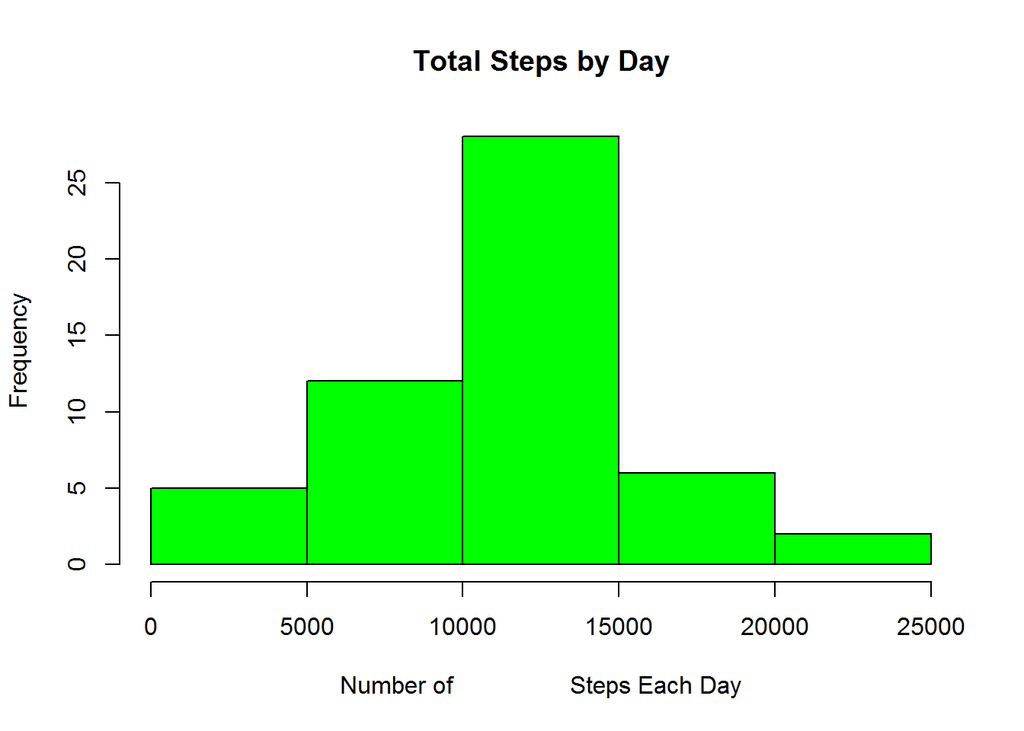

```r
dailySteps <- aggregate(steps ~ date, data, sum)
hist(dailySteps$steps, main = paste("Total Steps by Day"), xlab="Number of                 Steps Each Day", col="green")
```

```r
StepsMean <- mean(dailySteps$steps)
StepsMedian <- median(dailySteps$steps)
```

## What is the average daily activity pattern?

- Calculate the average steps for each interval for all days.
- Plot the average number of steps per day by interval.
- Find intervals with the most average steps.

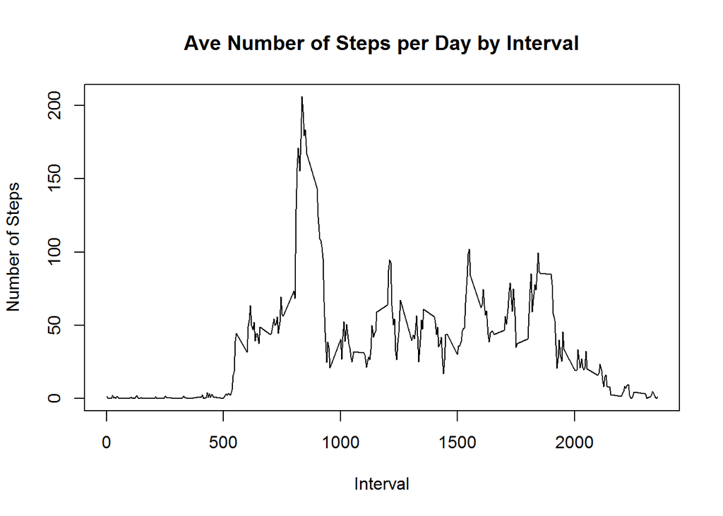

```r
intervalSteps <- aggregate(steps ~ interval, data, mean)

plot(intervalSteps$interval,intervalSteps$steps, type="l", xlab="Interval", ylab="Number of Steps", main="Ave Number of Steps per Day by Interval")
```

```r
intervalMax <- intervalSteps[which.max(intervalSteps$steps),1]
```

## Which 5-minute interval, on average across all the days in the dataset, contains the maximum number of steps?

The average 5-minute interval that contains the maximum number of steps is 835.

## Imputing Missing Values

### Total number of missing values

```r
missing <- sum(!complete.cases(data))
```

The total number of missing values is 2304.

The stategy used to insert missing data will be to input and average for each interval.

```r
modData <- transform(data, steps = ifelse(is.na(data$steps), intervalSteps$steps[match(data$interval, intervalSteps$interval)], data$steps))
summary(modData)
```

```
##      steps                date          interval
##  Min.   :  0.00   2012-10-01:  288   Min.   :   0.0
##  1st Qu.:  0.00   2012-10-02:  288   1st Qu.: 588.8
##  Median :  0.00   2012-10-03:  288   Median :1177.5
##  Mean   : 37.38   2012-10-04:  288   Mean   :1177.5
##  3rd Qu.: 27.00   2012-10-05:  288   3rd Qu.:1766.2
##  Max.   :806.00   2012-10-06:  288   Max.   :2355.0
##                   (Other)   :15840
```

Recalculate the daily steps with the revisions made.

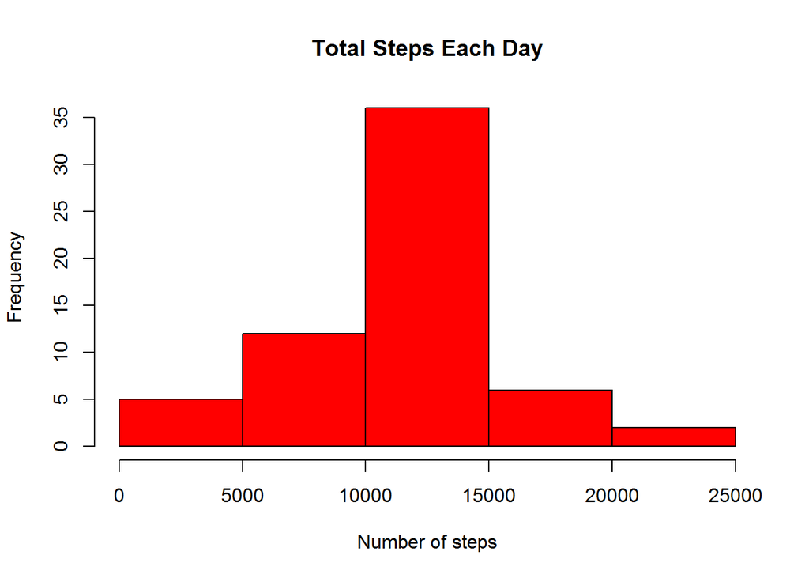

```r
modDailySteps <- aggregate(steps ~ date, modData, sum)
hist(modDailySteps$steps, main = paste("Total Steps Each Day"), col="red", xlab="Number of steps")
```